# R Overview

## Control Statements

R of course as all the typical control statements.

#### If statement

```r
if (my_first_var == "Hello World"){
  print("YAAAAAAAAY!!!!!")
}
```

```
[1] "YAAAAAAAAY!!!!!"
```

#### For Loop

```r
for (i in 1:length(my_vector)){
  print(i)
}
```

```
[1] 1
[1] 2
[1] 3
[1] 4
[1] 5
[1] 6
```

#### While Loop

```r
x = 0; y = 5
while (x < y){
  print(x)
  x = x + 1
}
```

```
[1] 0
[1] 1
[1] 2
[1] 3
[1] 4
```

#### Writing Functions

```r
std_dev <- function(values){
  avg <- mean(values)
  sq_devs <- (values - avg) **2
  return(sum(sq_devs) / (length(sq_devs) - 1))
}
std_dev(my_vector)
```

```
[1] 3.5
```

## Basic distributions and graphical analysis

#### Random Sequences

This is one of the areas R really shines. Having been designed by and for statisticians, the Base package of R has 20 distributions built in. Additionally distributions can be downloaded from packages.

For instance, lets generate 100 Random Nomral Variables.

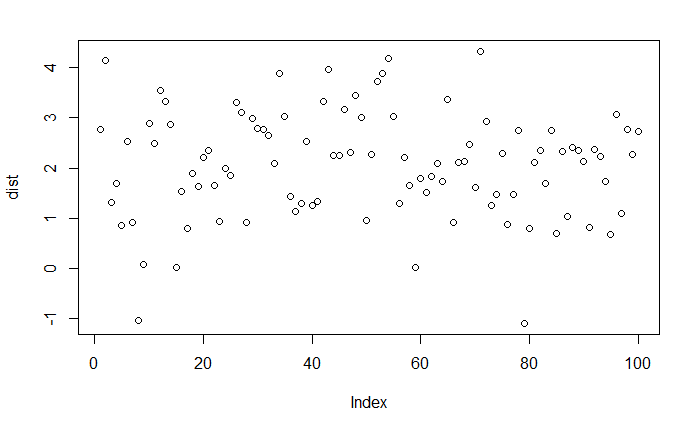

```r
dist <- rnorm(100, mean = 2, sd = 1)
plot(dist)
```

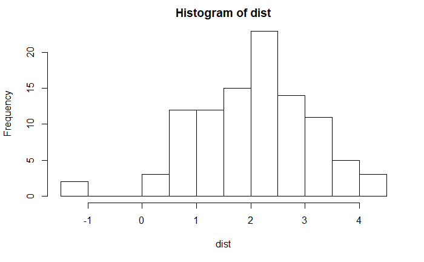

```r
hist(dist)
```

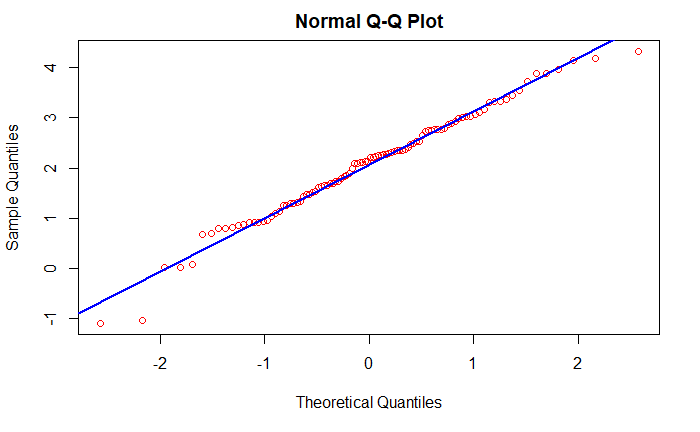

```r
# QQ Plot
qqnorm(dist, col = "red")
qqline(dist, col = "blue", lwd = 2)
```

Or maybe you want to random vectors generated according to a multinomial distribution.

Here, the definitions you do have to be careful of:  
n = number of vectors to draw (columns)  
size = number of objects to put in to buckets (# balls)  
prob = sets the number of and probability for each bucket

```r
mult <- rmultinom(n = 5, size = 1000, prob = c(.1, .05, .2, .4, .25))
mult
```

```
     [,1] [,2] [,3] [,4] [,5]
[1,]  112   98   97  122  105
[2,]   54   55   58   54   43
[3,]  190  194  188  201  218
[4,]  408  406  417  365  379
[5,]  236  247  240  258  255
```

Perhaps you’re interested in getting the probability density of of the normal distribution at a certain point.

## More on Using Distributions

R uses a standardized referencing system for accessing probabilities associated with distributions:  
r = random number generation (see above)  
q = quantiles  
d = density  
p = probability

#### Quantiles

First, we’ll quickly show some quantiles

```r
# Quantiles - The value that divides a distribution
# So by specifying 0.95, this will return the value below which 95% of observations in this distribution fall
qnorm(0.95, mean = 0, sd = 1, lower.tail = TRUE)
```

```
[1] 1.644854
```

```r
qnorm(0.5, mean = 2.4, sd = 1, lower.tail = TRUE)
```

```
[1] 2.4
```

```r
qnorm(0.2, mean = 0, sd = 1, lower.tail = TRUE)
```

```
[1] -0.8416212
```

#### Probabilities

Now, how about some probabilities.

The first value in all these functions can be a single number, or a sequence of numbers

```r
# Probability
pnorm(2.0, mean = 0, sd = 1, lower.tail = TRUE)
```

```
[1] 0.9772499
```

```r
pnorm(-1.67, mean = 0, sd = 2, lower.tail = TRUE)
```

```
[1] 0.2018589
```

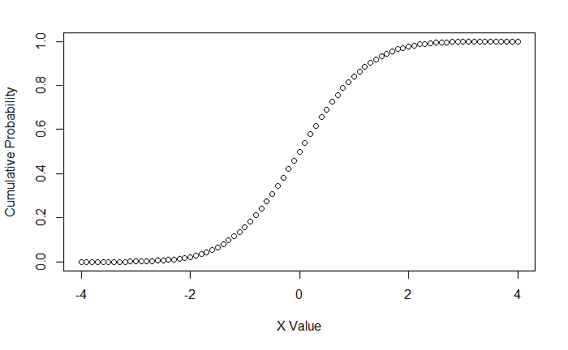

```r
# Plot of Normal Distribution
# Here the function is calculating the probability for the sequence from -4 to 4 in increments of .1.  Looping is automated
nom <- pnorm(seq(-4, 4, .1), mean = 0, sd = 1)
plot(seq(-4, 4, .1), nom, xlab = "X Value", ylab = "Cumulative Probability")
```

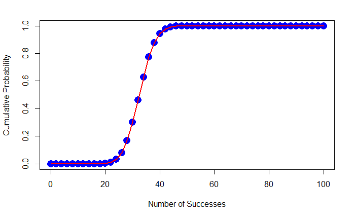

```r
# Binomial Probabilities
bin <- pbinom(seq(0, 100, 2), size = 100, prob = .33)
plot(seq(0, 100, 2), bin, col = "blue", pch = 16, cex = 2, xlab = "Number of Successes", ylab = "Cumulative Probability")
lines(seq(0, 100, 2), bin, col = "red", lwd = 2)
```

#### Density Functions

```r
# Density
dnorm(2.0, mean = 0, sd = 1)
```

```
[1] 0.05399097
```

```r
dnorm(-1.67, mean = 0, sd = 2)
```

```
[1] 0.1407601
```

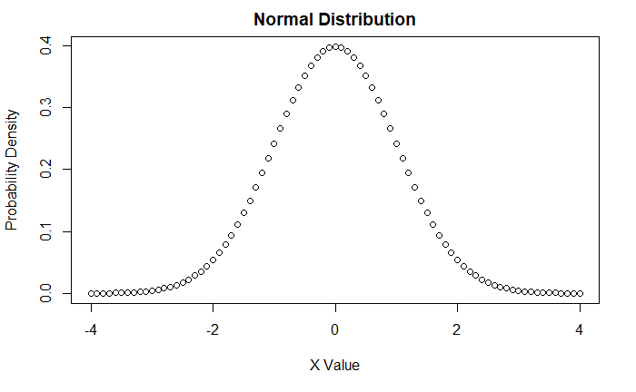

```r
# Plot of Normal Distribution
nom <- dnorm(seq(-4, 4, .1), mean = 0, sd = 1)
plot(seq(-4, 4, .1), nom, xlab = "X Value", ylab = "Probability Density", main = "Normal Distribution")
```

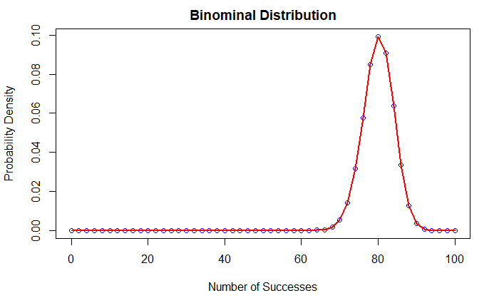

```r
# Binomial Probabilities
bin <- dbinom(seq(0, 100, 2), size = 100, prob = .8)
plot(seq(0, 100, 2), bin, col = "blue", pch = 1, cex = 1, xlab = "Number of Successes", ylab = "Probability Density", main = "Binominal Distribution")
lines(seq(0, 100, 2), bin, col = "red", lwd = 2)
```

#### Fun Data Operations

Piping operations. This is very useful if you need to chain multiple function calls together, passing the results of one to the next. It lets you accomplish this in a more readable format by using the ‘%>%’ pipe operator or chain operator. You can pipe together pretty much as many operations as you need. This is great for basic descriptive statistics and data exploration.

Important Note: The select function in dplyr conflicts with the function in MASS, so if you have both loaded, you have to specify using it by dplyr::select().

| cyl | gear | MilesGallon | Horsepower |
| --- | --- | --- | --- |
| 8 | 5 | 15.400 | 299.5000 |
| 8 | 3 | 15.050 | 194.1667 |
| 6 | 5 | 19.700 | 175.0000 |
| 6 | 4 | 19.750 | 116.5000 |
| 6 | 3 | 19.750 | 107.5000 |
| 4 | 5 | 28.200 | 102.0000 |
| 4 | 3 | 21.500 | 97.0000 |
| 4 | 4 | 26.925 | 76.0000 |

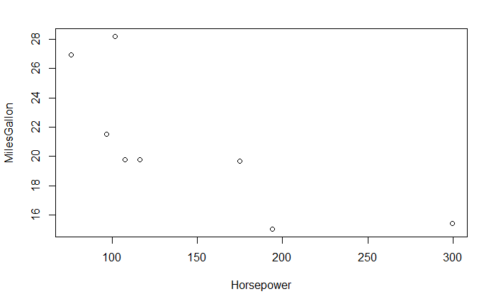

```r
# Dependencies
library(dplyr)
library(datasets)
library(magrittr)
data(mtcars)
mtcars %>%
  group_by(cyl, gear) %>%
  summarize(MilesGallon = mean(mpg), Horsepower = mean(hp)) %>%
  arrange(desc(Horsepower)) %>%
  dplyr::select(cyl, gear, MilesGallon, Horsepower) %>%
  print %$%
  plot(Horsepower, MilesGallon)
```

## Basic Statistics

The base R package includes most of the statistics functions you will need.

#### Basic Regression

Basic linear or multi-variable regression in R can be accomplished with the lm() function, or linear model.

```r
data(mtcars)
my_model <- lm(hp ~ disp, data = mtcars)
summary(my_model)
```

```
Call:
lm(formula = hp ~ disp, data = mtcars)

Residuals:
    Min      1Q  Median      3Q     Max
-48.623 -28.378  -6.558  13.588 157.562

Coefficients:
            Estimate Std. Error t value Pr(>|t|)
(Intercept)  45.7345    16.1289   2.836  0.00811 **
disp          0.4375     0.0618   7.080 7.14e-08 ***
---
Signif. codes:  0 ‘***’ 0.001 ‘**’ 0.01 ‘*’ 0.05 ‘.’ 0.1 ‘ ’ 1

Residual standard error: 42.65 on 30 degrees of freedom
Multiple R-squared:  0.6256,    Adjusted R-squared:  0.6131
F-statistic: 50.13 on 1 and 30 DF,  p-value: 7.143e-08
```

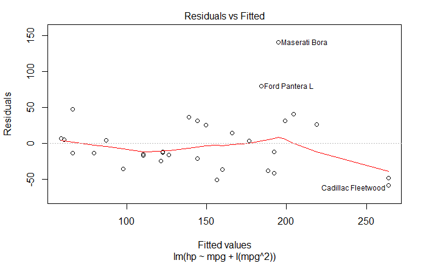

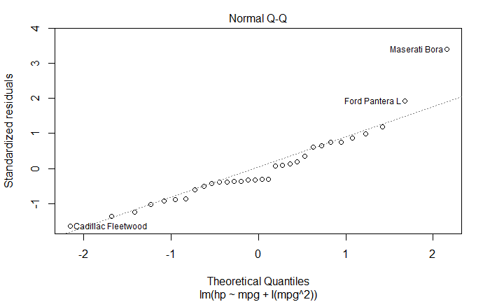

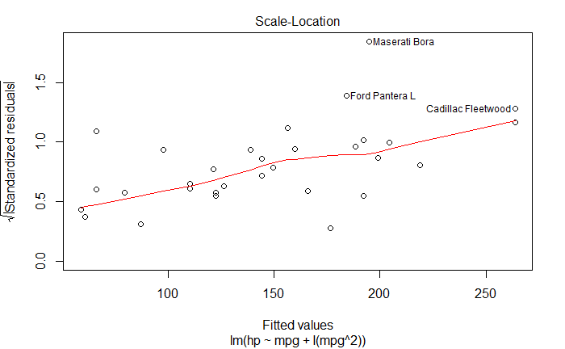

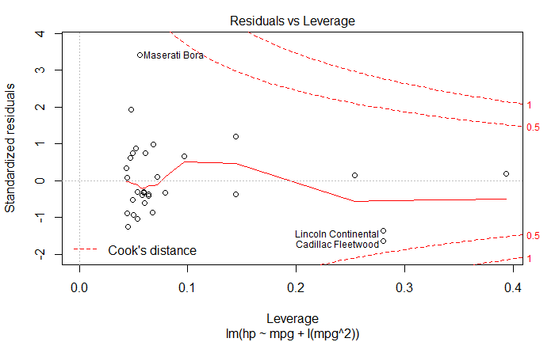

```r
# The I() function allows you to create interactions / squared terms on the fly
my_model2 <- lm(hp ~ mpg + I(mpg^2), data = mtcars)
plot(my_model2)
```

```r
summary(my_model2)
```

```
Call:
lm(formula = hp ~ mpg + I(mpg^2), data = mtcars)

Residuals:
   Min     1Q Median     3Q    Max
-58.78 -22.12 -12.94  25.51 140.04

Coefficients:
            Estimate Std. Error t value Pr(>|t|)
(Intercept) 470.8695    84.4624   5.575 5.14e-06 ***
mpg         -23.3445     8.0325  -2.906  0.00694 **
I(mpg^2)      0.3300     0.1804   1.830  0.07759 .
---
Signif. codes:  0 ‘***’ 0.001 ‘**’ 0.01 ‘*’ 0.05 ‘.’ 0.1 ‘ ’ 1

Residual standard error: 42.32 on 29 degrees of freedom
Multiple R-squared:  0.6436,    Adjusted R-squared:  0.619
F-statistic: 26.18 on 2 and 29 DF,  p-value: 3.187e-07
```

```r
# Or for fun, let's try it from scratch with our matrix operations
X <- cbind(rep(1, length(mtcars$mpg)), mtcars$mpg, mtcars$mpg **2)
X[1:5, 1:3]
```

```
     [,1] [,2]   [,3]
[1,]    1 21.0 441.00
[2,]    1 21.0 441.00
[3,]    1 22.8 519.84
[4,]    1 21.4 457.96
[5,]    1 18.7 349.69
```

```r
y <- mtcars$hp
y[1:5]
```

```
[1] 110 110  93 110 175
```

```r
results <- solve(t(X) %*% X) %*% (t(X) %*% y)
results
```

```
            [,1]
[1,] 470.8694716
[2,] -23.3445176
[3,]   0.3300288
```

```r
# Using the . in the formula definition means to utilize all variables, no interactions
my_model3 <- lm(hp ~ ., data = mtcars)
summary(my_model3)
```

```
Call:
lm(formula = hp ~ ., data = mtcars)

Residuals:
    Min      1Q  Median      3Q     Max
-38.681 -15.558   0.799  18.106  34.718

Coefficients:
            Estimate Std. Error t value Pr(>|t|)
(Intercept)  79.0484   184.5041   0.428  0.67270
mpg          -2.0631     2.0906  -0.987  0.33496
cyl           8.2037    10.0861   0.813  0.42513
disp          0.4390     0.1492   2.942  0.00778 **
drat         -4.6185    16.0829  -0.287  0.77680
wt          -27.6600    19.2704  -1.435  0.16591
qsec         -1.7844     7.3639  -0.242  0.81089
vs           25.8129    19.8512   1.300  0.20758
am            9.4863    20.7599   0.457  0.65240
gear          7.2164    14.6160   0.494  0.62662
carb         18.7487     7.0288   2.667  0.01441 *
---
Signif. codes:  0 ‘***’ 0.001 ‘**’ 0.01 ‘*’ 0.05 ‘.’ 0.1 ‘ ’ 1

Residual standard error: 25.97 on 21 degrees of freedom
Multiple R-squared:  0.9028,    Adjusted R-squared:  0.8565
F-statistic:  19.5 on 10 and 21 DF,  p-value: 1.898e-08
```

R is also very easy to use for Kernel Density Estimates.

```r
density(dist)
```

```
Call:
    density.default(x = dist)

Data: dist (100 obs.);  Bandwidth 'bw' = 0.3793

       x                 y
 Min.   :-2.2244   Min.   :0.0001856
 1st Qu.:-0.3018   1st Qu.:0.0185213
 Median : 1.6209   Median :0.0740167
 Mean   : 1.6209   Mean   :0.1298971
 3rd Qu.: 3.5435   3rd Qu.:0.2558216
 Max.   : 5.4662   Max.   :0.3691031
```

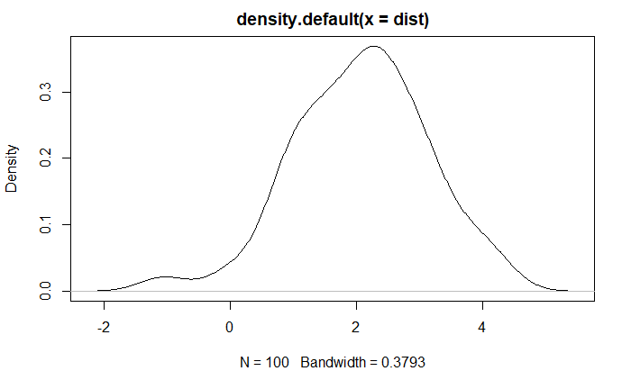

```r
plot(density(dist))
```